# Spatial Analysis of Environmental Factors Related to Large Tornado Groups

Research to be submitted to the **Electronic Journal of Severe Storms Meteorology**

Q: What are the broad geographic variations in CAPE and shear associated with tornado groups? How widely do these environmental characteristics vary geographically?

Q: Which environmental variable (CAPE or shear) best explains group-level average tornado energy? Which variable best explains worst-case group-level tornado energy?

Why is this important? Tornado groups represent the most concentrated large-scale risk for damage and casualties.

This analysis is done at the scale of tornado groups rather than at regional or local scales.

To minimize controvery related to terminology tornado ‘group’ is used to refer to tornadoes occurring close together in space and time. The word ‘outbreak’ has a specific definition that is not strictly adhered to here.

The analysis and modeling makes use of the Storm Prediction Center’s tornado data set.

Set working directory and load packages.

```r
library(tidyverse)
library(lubridate)
library(sf)
library(tmap)
library(USAboundaries)
```

The newest GIS shapefile contains missing geometries for more than 30% of the tornadoes. The number of missing geometries is highest after 1995. Instead use the csv file from https://www.spc.noaa.gov/wcm/#data Use the start lon/lat and create a `sp` object then convert to `sf`. Set the coordinate reference system (crs) to ESPG 4326.

```r
Tor.df <- read.csv(file = "1950-2017_actual_tornadoes.csv")
Tor.spdf <- Tor.df
rm(Tor.df)
sp::coordinates(Tor.spdf) <- ~ slon + slat
Tor.sfdf <- st_as_sf(Tor.spdf)
st_crs(Tor.sfdf) <- 4326
```

Remove tornadoes in Hawaii, Alaska, and Puerto Rico and those occurring before 1994. For missing EF ratings use https://www.spc.noaa.gov/wcm/OneTor_F-scale-modifications.pdf

```r
Tor.sfdf <- Tor.sfdf %>%
  filter(yr >= 1994, #start in 1994 because of comprehensive radar
         st != c("AK", "PR", "HI")) %>% #remove tornadoes occurring in Alaska, Puerto Rico, and Hawaii
  mutate(mag = ifelse(mag == -9 & len <= 5, 0, mag),
         mag = ifelse(mag == -9 & len > 5, 1, mag))
```

Add a data/time column also add columns for path length, width, and area in metric units. Leave the time zone as native CDT. Create a convective day (6AM to 6AM) column taking hours 00:00:00 -> 05:59:59 and assigning it to the previous date (this associates the previous day’s date to tornadoes occurring up to 6 hours after local midnight).

```r
Tor.sfdf <- Tor.sfdf %>%
  mutate(dy = format(as.Date(date,format="%m/%d/%y"), "%d"),
         DateTime = as.POSIXct(paste(yr, mo, dy, time), format = "%Y%m%d%H:%M:%S"),
         Hour = hour(DateTime),
         Year = year(DateTime),
         cDateTime = DateTime - as.difftime(6, unit = "hours"),
         cDate = as.Date(cDateTime),
         Length = len * 1609.34,
         Length = ifelse(Length == 0, min(Length[Length > 0]), Length), #takes care of zero length
         Width = wid * .9144,
         Width = ifelse(Width == 0, min(Width[Width > 0]), Width), #takes care of zero width
         Width = ifelse(Year >= 1995, Width * pi/4, Width), #takes care of change: avg to max
         cas = inj + fat,
         AreaPath = Length * Width,
         Ma = factor(month.abb[mo], levels = month.abb[1:12])) %>%
  sf::st_sf()
max(Tor.sfdf$yr)
```

```
## [1] 2017
```

The geometry type is `POINT`. Each tornado is a single location (start location).

Add energy dissipation per tornado. Use the empirical model for tornado winds by EF rating taken from Table 3-1 of NRC 2007. Percent area by EF rating for each EF category. Threshold wind speeds (m/s) are a lower bound 3 sec gusts on the operational EF Scale (Table 2-1 of NRC2007). This is based on work by Fricker et al.

$E = A_p \rho \sum_{j=0}^{J} w_j v_j^{3},$ where $A_p$ is the area of the path, $\rho$ is area density [1 kg/m^3] $v_j$ is the midpoint wind speed for each rating, and $w_j$ is the corresponding fraction of path area by EF rating. With no upper bound on the EF5 wind speeds, the midpoint wind speed is set at 97 m~s$^{-1}$ (7.5 m~s$^{-1}$ above the threshold wind speed consistent with the EF4 midpoint speed relative to its threshold)

```r
perc <- c(1, 0, 0, 0, 0, 0,
         .772, .228, 0, 0, 0, 0,
         .616, .268, .115, 0, 0, 0,
         .529, .271, .133, .067, 0, 0,
         .543, .238, .131, .056, .032, 0,
         .538, .223, .119, .07, .033, .017)
percM <- matrix(perc, ncol = 6, byrow = TRUE)
threshW <- c(29.06, 38.45, 49.62, 60.8, 74.21, 89.41)
midptW <- c(diff(threshW)/2 + threshW[-length(threshW)], threshW[length(threshW)] + 7.5)
ef <- Tor.sfdf$mag + 1
EW3 <- numeric()
for(i in 1:length(ef)) EW3[i] = midptW^3 %*% percM[ef[i], ]
Tor.sfdf <- Tor.sfdf %>%
  mutate(ED = EW3 * AreaPath)
```

Determine the distance between tornadoes in space and time. Use a planar projection not lat/lon. See https://epsg.io/102004. Extract the coordinates of the start locations as a N by 2 matrix of numbers, where N is the number of tornadoes. Also extract the date-time as a vector of class `POSIXct`.

```r
Tor.sfdfT <- st_transform(Tor.sfdf, crs = 102004)
space <- st_coordinates(Tor.sfdfT)
time <- Tor.sfdf$DateTime
```

Next compute pairwise Euclidean distances in space and, separately, in time using the `dist()` function. Divide the spatial distance by 10 so that the values are commensurate with the time ‘distance’ based on the assumption of 10 meters every second for an average speed of tornado-generating storms.

Compare: Distance from New York to Denver is 2.622 x 10^6 meters. There are 3.154 x 10^7 seconds in a year. This will capture the historic multiday tornado outbreaks. For analysis we want to consider each day in the multiday group separately. As the value of the divisor increases cluster areas get larger.

```r
ds <- dist(space) / 10
dt <- dist(time)
dst <- ds + dt
rm(ds, dt) # helps control memory allocation
```

Distances are saved as an object of class `dist` containing a vector of length N * (N-1)/2, which is the number of unique point pairs.

Next group the tornadoes based on the space-time distances. This is done with the `hclust()` (hierarchical cluster) function. Initially, each tornado is assigned to its own group and then the algorithm joins the two closest tornadoes determined by values in `dst`. The algorithm continues by joining tornadoes (and tornado groups) until there is a single large group.

The single linkage method (`method = "single"`) is related to the minimal spanning tree (MST) and adopts a ‘friends of friends’ grouping strategy. An edge-weighted graph is a graph where each edge has a weight (or cost). Here weights are space-time distances between tornadoes. A MST of an edge-weighted graph is a spanning tree whose weight (the sum of the weights of its edges) is no larger than the weight of any other spanning tree. A spanning tree of a graph on N vertices (tornado centroids) is a subset of N-1 edges that form a tree (Skiena 1990, p. 227).

The `cutree()` function is used to extract a group number for each tornado. Tornadoes in each group are close in space & time. Here the tree is cut at a height of 100000 space-time units. Making `h` smaller results in smaller groups (fewer tornadoes per group).

```r
stime <- proc.time()
tree <- hclust(dst, method = "single")
groupNumber <- as.integer(cutree(tree, h = 100000))
proc.time() - stime
```

```
##    user  system elapsed
##  21.155   1.696  22.931
```

Add the group number to each tornado.

```r
Tor.sfdfT$groupNumber <- groupNumber
```

Compute group-level statistics. Keep only tornado groups with at least 30 tornadoes.

```r
Groups.sfdfT <- Tor.sfdfT %>%
  group_by(groupNumber) %>%
  summarize(Year = first(Year),
            Month = first(mo),
            FirstDate = first(date),
            LastDate = last(date),
            Name = paste(FirstDate, "to", LastDate),
            FirstcDate = first(cDate),
            LastcDate = last(cDate),
            ncD = n_distinct(cDate),
            nT = n(),
            n0 = sum(mag == 0),
            n1 = sum(mag == 1),
            n2 = sum(mag == 2),
            n3 = sum(mag == 3),
            n4 = sum(mag == 4),
            n5 = sum(mag == 5),
            GroupTotalED = sum(ED),
            Name2 = paste(round(GroupTotalED/10^12), "TW"),
            maxEF = max(mag),
            nD = n_distinct(date),
            StartTime = first(DateTime),
            EndTime = last(DateTime),
            Duration = difftime(EndTime, StartTime, units = "secs")) %>%
  filter(nT >= 30)
dim(Groups.sfdfT)
```

```
## [1] 198  24
```

Make some tables: Top 10 groups by number of tornadoes, energy dissipation, and duration.

```r
Groups.sfdfT %>%
  top_n(n = 10, wt = nT) %>%
  arrange(desc(nT))
```

```
## Simple feature collection with 10 features and 23 fields
## geometry type:  MULTIPOINT
## dimension:      XY
## bbox:           xmin: -1018513 ymin: -984041.5 xmax: 1799330 ymax: 1093755
## epsg (SRID):    102004
## proj4string:    +proj=lcc +lat_1=33 +lat_2=45 +lat_0=39 +lon_0=-96 +x_0=0 +y_0=0 +datum=NAD83 +units=m +no_defs
## # A tibble: 10 x 24
##    groupNumber  Year Month FirstDate LastDate Name   FirstcDate LastcDate
##          <int> <dbl> <int> <fct>     <fct>    <chr>  <date>     <date>
##  1        3466  2011     4 4/22/11   4/28/11  4/22/… 2011-04-22 2011-04-28
##  2        1954  2003     5 5/3/03    5/11/03  5/3/0… 2003-05-03 2003-05-10
##  3        3483  2011     5 5/21/11   5/27/11  5/21/… 2011-05-21 2011-05-27
##  4        2155  2004     5 5/28/04   5/31/04  5/28/… 2004-05-28 2004-05-31
##  5        3461  2011     4 4/14/11   4/16/11  4/14/… 2011-04-14 2011-04-16
##  6        2767  2007     5 5/3/07    5/7/07   5/3/0… 2007-05-03 2007-05-06
##  7        2990  2008     6 6/3/08    6/8/08   6/3/0… 2008-06-02 2008-06-08
##  8        4142  2015     5 5/5/15    5/11/15  5/5/1… 2015-05-05 2015-05-11
##  9        1116  1999     1 1/21/99   1/22/99  1/21/… 1999-01-21 1999-01-22
## 10        3842  2013     5 5/27/13   6/1/13   5/27/… 2013-05-27 2013-05-31
## # ... with 16 more variables: ncD <int>, nT <int>, n0 <int>, n1 <int>,
## #   n2 <int>, n3 <int>, n4 <int>, n5 <int>, GroupTotalED <dbl>,
## #   Name2 <chr>, maxEF <dbl>, nD <int>, StartTime <dttm>, EndTime <dttm>,
## #   Duration <time>, geometry <MULTIPOINT [m]>
```

```r
Groups.sfdfT %>%
  top_n(n = 10, wt = GroupTotalED) %>%
  arrange(desc(GroupTotalED))
```

```
## Simple feature collection with 10 features and 23 fields
## geometry type:  MULTIPOINT
## dimension:      XY
## bbox:           xmin: -775110.8 ymin: -984041.5 xmax: 1799330 ymax: 1093755
## epsg (SRID):    102004
## proj4string:    +proj=lcc +lat_1=33 +lat_2=45 +lat_0=39 +lon_0=-96 +x_0=0 +y_0=0 +datum=NAD83 +units=m +no_defs
## # A tibble: 10 x 24
##    groupNumber  Year Month FirstDate LastDate Name   FirstcDate LastcDate
##          <int> <dbl> <int> <fct>     <fct>    <chr>  <date>     <date>
##  1        3466  2011     4 4/22/11   4/28/11  4/22/… 2011-04-22 2011-04-28
##  2        3483  2011     5 5/21/11   5/27/11  5/21/… 2011-05-21 2011-05-27
##  3        3290  2010     4 4/23/10   4/25/10  4/23/… 2010-04-23 2010-04-25
##  4        1954  2003     5 5/3/03    5/11/03  5/3/0… 2003-05-03 2003-05-10
##  5          24  1994     3 3/27/94   3/28/94  3/27/… 1994-03-27 1994-03-28
##  6        3461  2011     4 4/14/11   4/16/11  4/14/… 2011-04-14 2011-04-16
##  7        3623  2012     2 2/28/12   3/3/12   2/28/… 2012-02-28 2012-03-03
##  8        2930  2008     2 2/5/08    2/6/08   2/5/0… 2008-02-05 2008-02-05
##  9        2979  2008     5 5/22/08   5/24/08  5/22/… 2008-05-22 2008-05-24
## 10        2767  2007     5 5/3/07    5/7/07   5/3/0… 2007-05-03 2007-05-06
## # ... with 16 more variables: ncD <int>, nT <int>, n0 <int>, n1 <int>,
## #   n2 <int>, n3 <int>, n4 <int>, n5 <int>, GroupTotalED <dbl>,
## #   Name2 <chr>, maxEF <dbl>, nD <int>, StartTime <dttm>, EndTime <dttm>,
## #   Duration <time>, geometry <MULTIPOINT [m]>
```

```r
Groups.sfdfT %>%
  top_n(n = 10, wt = Duration) %>%
  arrange(desc(Duration))
```

```
## Simple feature collection with 10 features and 23 fields
## geometry type:  MULTIPOINT
## dimension:      XY
## bbox:           xmin: -1018513 ymin: -984041.5 xmax: 1733423 ymax: 1093755
## epsg (SRID):    102004
## proj4string:    +proj=lcc +lat_1=33 +lat_2=45 +lat_0=39 +lon_0=-96 +x_0=0 +y_0=0 +datum=NAD83 +units=m +no_defs
## # A tibble: 10 x 24
##    groupNumber  Year Month FirstDate LastDate Name   FirstcDate LastcDate
##          <int> <dbl> <int> <fct>     <fct>    <chr>  <date>     <date>
##  1        1954  2003     5 5/3/03    5/11/03  5/3/0… 2003-05-03 2003-05-10
##  2        3172  2009     6 6/13/09   6/19/09  6/13/… 2009-06-13 2009-06-19
##  3        3483  2011     5 5/21/11   5/27/11  5/21/… 2011-05-21 2011-05-27
##  4        4336  2016     5 5/21/16   5/27/16  5/21/… 2016-05-21 2016-05-27
##  5        3466  2011     4 4/22/11   4/28/11  4/22/… 2011-04-22 2011-04-28
##  6        4142  2015     5 5/5/15    5/11/15  5/5/1… 2015-05-05 2015-05-11
##  7        2990  2008     6 6/3/08    6/8/08   6/3/0… 2008-06-02 2008-06-08
##  8          86  1994     6 6/6/94    6/11/94  6/6/9… 1994-06-06 1994-06-11
##  9         133  1994     7 7/4/94    7/8/94   7/4/9… 1994-07-03 1994-07-08
## 10        3842  2013     5 5/27/13   6/1/13   5/27/… 2013-05-27 2013-05-31
## # ... with 16 more variables: ncD <int>, nT <int>, n0 <int>, n1 <int>,
## #   n2 <int>, n3 <int>, n4 <int>, n5 <int>, GroupTotalED <dbl>,
## #   Name2 <chr>, maxEF <dbl>, nD <int>, StartTime <dttm>, EndTime <dttm>,
## #   Duration <time>, geometry <MULTIPOINT [m]>
```

```r
Groups.sfdfT %>%
  top_n(n = 10, wt = nD) %>%
  arrange(desc(nD))
```

```
## Simple feature collection with 10 features and 23 fields
## geometry type:  MULTIPOINT
## dimension:      XY
## bbox:           xmin: -1018513 ymin: -984041.5 xmax: 1733423 ymax: 1093755
## epsg (SRID):    102004
## proj4string:    +proj=lcc +lat_1=33 +lat_2=45 +lat_0=39 +lon_0=-96 +x_0=0 +y_0=0 +datum=NAD83 +units=m +no_defs
## # A tibble: 10 x 24
##    groupNumber  Year Month FirstDate LastDate Name   FirstcDate LastcDate
##          <int> <dbl> <int> <fct>     <fct>    <chr>  <date>     <date>
##  1        1954  2003     5 5/3/03    5/11/03  5/3/0… 2003-05-03 2003-05-10
##  2        3172  2009     6 6/13/09   6/19/09  6/13/… 2009-06-13 2009-06-19
##  3        3466  2011     4 4/22/11   4/28/11  4/22/… 2011-04-22 2011-04-28
##  4        3483  2011     5 5/21/11   5/27/11  5/21/… 2011-05-21 2011-05-27
##  5        4142  2015     5 5/5/15    5/11/15  5/5/1… 2015-05-05 2015-05-11
##  6        4336  2016     5 5/21/16   5/27/16  5/21/… 2016-05-21 2016-05-27
##  7          86  1994     6 6/6/94    6/11/94  6/6/9… 1994-06-06 1994-06-11
##  8        1776  2002     5 5/4/02    5/9/02   5/4/0… 2002-05-04 2002-05-08
##  9        2990  2008     6 6/3/08    6/8/08   6/3/0… 2008-06-02 2008-06-08
## 10        3842  2013     5 5/27/13   6/1/13   5/27/… 2013-05-27 2013-05-31
## # ... with 16 more variables: ncD <int>, nT <int>, n0 <int>, n1 <int>,
## #   n2 <int>, n3 <int>, n4 <int>, n5 <int>, GroupTotalED <dbl>,
## #   Name2 <chr>, maxEF <dbl>, nD <int>, StartTime <dttm>, EndTime <dttm>,
## #   Duration <time>, geometry <MULTIPOINT [m]>
```

Map the locations (start points) of the top 12 tornado groups by energy dissipation. First select the top 12 groups by total ED. Then create a simple features data frame using only the tornadoes in these groups by filtering on group number.

```r
df <- as.data.frame(Groups.sfdfT) %>%
  top_n(n = 12, wt = GroupTotalED)

sfdf <- Tor.sfdfT %>%
   filter(groupNumber %in% df$groupNumber) %>%
   mutate(EF = factor(mag))

sfdf2 <- left_join(sfdf, df, by = "groupNumber") %>%
  arrange(desc(GroupTotalED))
```

Get state borders and use the `tm_shape()` function.

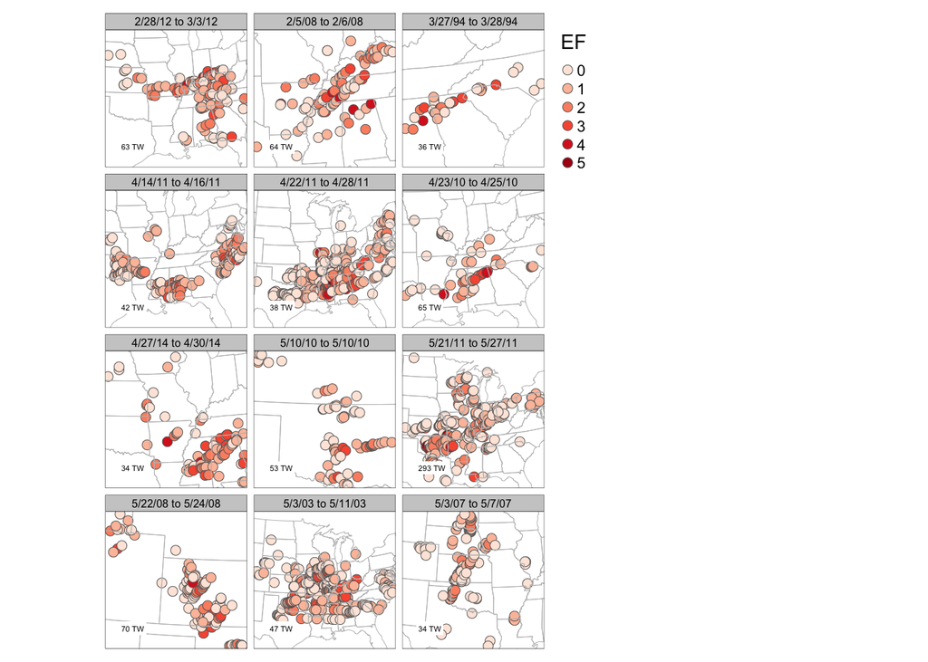

```r
sts <- state.name[!state.name %in% c("Alaska", "Hawaii")]
stateBorders <- us_states(states = sts)

tm_shape(sfdf2) +
  tm_facets(by = "Name", ncol = 3)  +
  tm_symbols(col = "EF", palette = "Reds", n = 6) +
  tm_credits(text = df$Name2, position = c("left", "bottom"), bg.color = "white") +
tm_shape(stateBorders) +
  tm_borders(col = "grey") +
#  tm_compass() + tm_scale_bar() +
  tm_layout(legend.outside = TRUE)
```

Distribution of the number of days.

```r
dfnD <- as.data.frame(Groups.sfdfT) %>%
  arrange(desc(nD))
table(dfnD$nD)
```

```
##
##  1  2  3  4  5  6  7  9
## 10 63 67 31 17  4  5  1
```

```r
as.data.frame(Groups.sfdfT) %>%
  filter(nD >= 4) %>%
  count(Month) %>%
  mutate(prop = prop.table(n))
```

```
## # A tibble: 8 x 3
##   Month     n   prop
##   <int> <int>  <dbl>
## 1     2     1 0.0172
## 2     3     2 0.0345
## 3     4     8 0.138
## 4     5    23 0.397
## 5     6    14 0.241
## 6     7     2 0.0345
## 7     8     3 0.0517
## 8     9     5 0.0862
```

```r
as.data.frame(Groups.sfdfT) %>%
  count(Month, nD) %>%
  mutate(prop = prop.table(n))
```

```
## # A tibble: 48 x 4
##    Month    nD     n    prop
##    <int> <int> <int>   <dbl>
##  1     1     1     1 0.00505
##  2     1     2     3 0.0152
##  3     1     3     3 0.0152
##  4     2     2     5 0.0253
##  5     2     3     3 0.0152
##  6     2     5     1 0.00505
##  7     3     2     4 0.0202
##  8     3     3     3 0.0152
##  9     3     4     1 0.00505
## 10     3     5     1 0.00505
## # ... with 38 more rows
```

Filter on tornadoes to remove those not part of a large group. Group by group number and convective dates. Remove group days with fewer than 10 tornadoes.

```r
BigDaysInLargeGroups.sfdfT <- Tor.sfdfT %>%
  filter(groupNumber %in% Groups.sfdfT$groupNumber) %>%
  group_by(groupNumber, cDate) %>%
  summarize(nT = n(),
            GroupDayTotalED = sum(ED),
            GroupDayMaxED = max(ED),
            GroupDayMeanED = mean(ED),
            cDate1 = first(cDate)) %>%
  filter(nT >= 10) %>%
  mutate(Year = year(cDate1),
         Mo = month(cDate1),
         Month = format(cDate1, "%m"), # this is needed to preserve the leading zeros
         Day = format(cDate1, "%d"))
```

There are 399 big days in large groups. These will be used for further analysis and modeling.

Table the number of days per group. Also look at the day counts by year and month.

```r
table(table(BigDaysInLargeGroups.sfdfT$groupNumber))
```

```
##
##  1  2  3  4  5  6  7  8
## 65 93 24 10  3  1  1  1
```

```r
table(BigDaysInLargeGroups.sfdfT$Year)
```

```
##
## 1994 1995 1996 1997 1998 1999 2000 2001 2002 2003 2004 2005 2006 2007 2008
##   15   19   13   10   16   16   12   15   10   22   28   14   12   11   27
## 2009 2010 2011 2012 2013 2014 2015 2016 2017
##   14   22   25   10   15   14   22   14   23
```

```r
table(BigDaysInLargeGroups.sfdfT$Month)
```

```
##
##  01  02  03  04  05  06  07  08  09  10  11  12
##  10  12  17  71 130  80   8   7  19  17  19   9
```

Top 10 biggest tornado days within the largest groups.

```r
BigDaysInLargeGroups.sfdfT %>%
  top_n(n = 10, nT) %>%
  arrange(desc(nT))
```

```
## Simple feature collection with 399 features and 11 fields
## geometry type:  MULTIPOINT
## dimension:      XY
## bbox:           xmin: -1932981 ymin: -1348247 xmax: 2011477 ymax: 1117908
## epsg (SRID):    102004
## proj4string:    +proj=lcc +lat_1=33 +lat_2=45 +lat_0=39 +lon_0=-96 +x_0=0 +y_0=0 +datum=NAD83 +units=m +no_defs
## # A tibble: 399 x 12
## # Groups:   groupNumber [198]
##    groupNumber cDate         nT GroupDayTotalED GroupDayMaxED
##          <int> <date>     <int>           <dbl>         <dbl>
##  1        3466 2011-04-27   164         2.20e14       3.85e13
##  2        3466 2011-04-26   121         4.70e13       1.27e13
##  3        1116 1999-01-21   100         1.21e13       1.63e12
##  4        2000 2003-06-24    95         2.91e12       1.13e12
##  5        1954 2003-05-04    91         3.13e13       7.56e12
##  6        2767 2007-05-05    90         8.46e12       1.80e12
##  7        2319 2004-11-23    88         1.58e13       5.23e12
##  8        2155 2004-05-30    87         2.19e12       6.00e11
##  9        2930 2008-02-05    86         4.18e13       1.82e13
## 10        3646 2012-04-14    85         3.27e13       1.05e13
## # ... with 389 more rows, and 7 more variables: GroupDayMeanED <dbl>,
## #   cDate1 <date>, Year <dbl>, Mo <dbl>, Month <chr>, Day <chr>,
## #   geometry <MULTIPOINT [m]>
```

Extract the geographic centroids of tornado genesis on big tornado days by creating an `sf` object using `st_centroid()` that reduces the MULTIPOINT geometry to a POINT geometry. Compute the area of the group and the number of tornadoes per area (density).

```r
groupDayCentroids.sfdfT <- st_centroid(BigDaysInLargeGroups.sfdfT)
groupDayCentroids.sfdfT$groupArea <- st_area(st_convex_hull(BigDaysInLargeGroups.sfdfT))
groupDayCentroids.sfdfT$groupDensity <- groupDayCentroids.sfdfT$nT/groupDayCentroids.sfdfT$groupArea
```

Plot the centroid for each group day and size the aesthetic by the number of tornadoes.

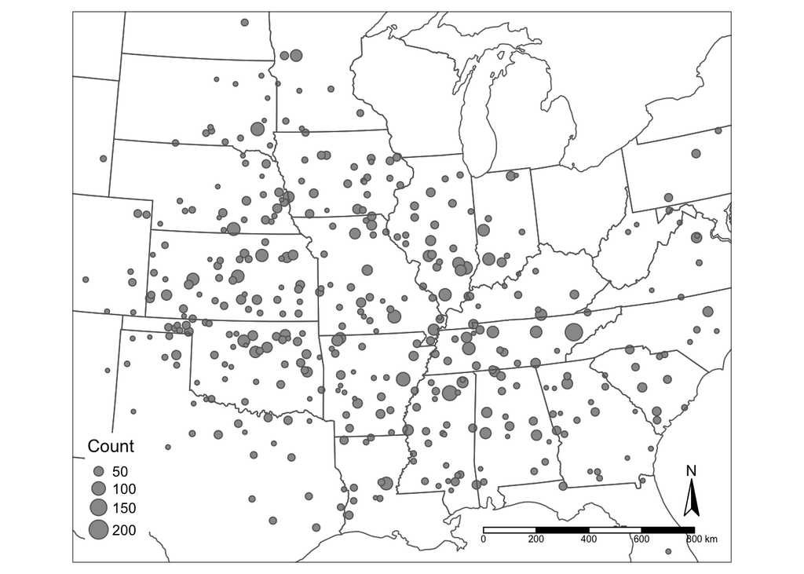

```r
tm_shape(groupDayCentroids.sfdfT) +
  tm_symbols(size = "nT", title.size = "Count", legend.size.is.portrait = TRUE) +
tm_shape(stateBorders) +
  tm_borders() +
  tm_compass() + tm_scale_bar() +
  tm_layout(legend.bg.color = "white", legend.text.size = .75)
```

Tornado group day centers do not have an obvious population bias.

Time series graphs

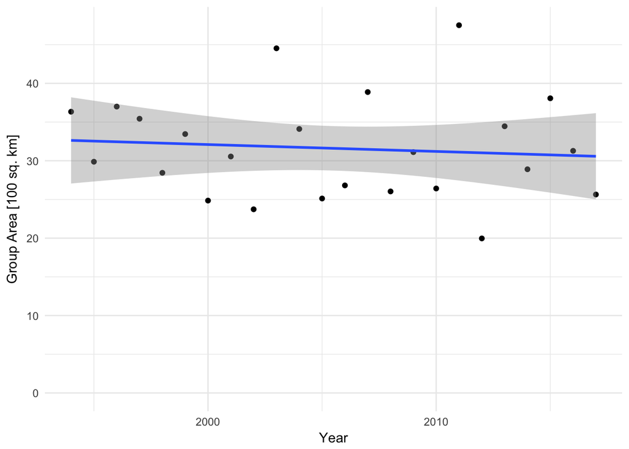

```r
groupDayCentroids.sfdfT %>%
  group_by(Year) %>%
  summarize(avgArea = mean(groupArea)) %>%
  ggplot(., aes(x = Year, y = as.numeric(avgArea) / 10^10)) +
    scale_y_continuous(limits = c(0, NA)) +
    geom_point() +
    geom_smooth(method = lm) +
    ylab("Group Area [100 sq. km]") +
    theme_minimal()
```

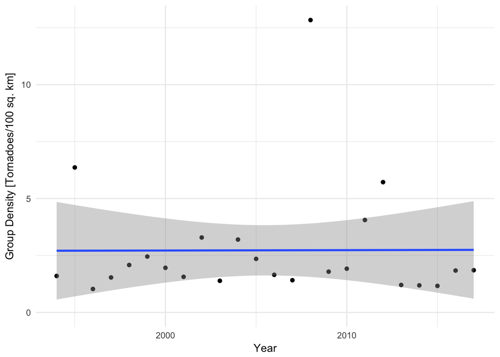

```r
groupDayCentroids.sfdfT %>%
  group_by(Year) %>%
  summarize(avgDensity = mean(groupDensity)) %>%
  ggplot(., aes(x = Year, y = as.numeric(avgDensity) * 10^10)) +
    scale_y_continuous(limits = c(0, NA)) +
    geom_point() +
    geom_smooth(method = lm) +
    ylab("Group Density [Tornadoes/100 sq. km]") +
    theme_minimal()
```